# Meta-Analysis of Genome-Wide Association Studies of Human Milk Oligosaccharide Composition

Author

Uma Agarwal  
Mentor: Kelsey Johnson, PhD

## **Abstract:**

Human milk oligosaccharides (HMOs) are bioactive components of human milk that contribute to infant nutrition, immune development, and gut microbiome composition. Genome-wide association study (GWAS) summary statistics from the MILK (n = 540), CHILD (n = 980), and Lifelines NEXT (n = 524) cohorts were harmonized and meta-analyzed using METAL to identify genetic determinants of HMO composition. The three-cohort meta-analysis identified seven genome-wide significant loci, while a secondary meta-analysis of MILK and CHILD identified one additional locus. In total, eight loci were associated with HMO composition, including three putatively novel associations. These findings demonstrate that meta-analysis increases statistical power to identify genetic variants influencing HMO composition and provide candidate loci for future functional investigation.

## **Introduction:**

Human milk oligosaccharides (HMOs) are the third most abundant non-water compounds of human milk, following lactose and lipids. While not directly metabolized by the infant, HMOs are bioactive components of breast milk that contribute to infant nutrition, immune development, and microbiome composition (1).

Several distinct HMO structures have been identified, all of which originate from lactose; these structures are synthesized through sequential enzymatic additions of functional groups, such as fucose, sialic acid, or N-acetylglucosamine. Notably, the FUT2 enzyme catalyzes the alpha-1,2 addition of fucose to lactose to produce 2’-fucosyllactose (2’FL).

Milk from a single lactating mother can contain 12-20 distinct HMOs in varying concentrations. Understanding the maternal genetic determinants of HMO composition may improve understanding of lactation biology and inter-individual variation in milk composition.

To our knowledge, to date there have been no meta-analyses conducted to examine the genetic associations of HMO composition in human milk. Analyses of the genetics behind HMO composition in individual cohorts suffer from small sample sizes and low statistical power, potentially obscuring real associations. Here, by incorporating GWAS summary statistics from the MILK study (2), CHILD study (3), and Lifelines NEXT cohort (4), we aim to utilize meta-analysis pipelines to improve statistical power and reveal further genetic associations with HMO composition in human milk.

## **Methods:**

Genome-wide association summary-level statistics from three independent cohorts: MILK study (n=540), CHILD study (n=980), and Dutch Lifelines NEXT cohort (n=524), were harmonized in preparation for meta-analysis. Summary statistics from CHILD and Lifelines were each converted from genomic build GRCh37 (hg19) to GRCh38 (hg38) using the command-line tool UCSC LiftOver (5). Additionally, all variant identifiers were standardized across cohorts, and variants for which the beta values, standard errors, and/or p-values were missing were removed.

For the meta-analysis of all cohorts, METAL was used (6). METAL’s `SCHEME STDERR` was used to produce effect size estimates of each variant across all cohorts. Additionally, the `ANALYZE HETEROGENEITY` option was used to produce heterogeneity statistics across all cohorts. Sample sizes and allele frequencies were specified to METAL to allow for accurate effect size weightage.

Two meta-analysis pipelines were run: one in which phenotypes shared by all three cohorts were meta-analyzed, and a second run in which additional phenotypes shared by only the MILK and CHILD cohorts were meta-analyzed. There were no phenotypes shared only by the MILK and Lifelines cohorts. Across the MILK, CHILD, and Lifelines cohorts, thirteen HMO phenotypes were analyzed, plus three additional summary-level phenotypes. Across the MILK and CHILD cohorts, six additional phenotypes were meta-analyzed (Figure 1).

Post-analysis summary tables were constructed in R using the `data.table` and `tidyverse` package libraries. Forest plots were constructed in R using `ggplot2`, and QQplots and Manhattan plots additionally used the `qqman` library. Locuszoom plots were constructed in R using the `locuszoomr`, `ensembldb`, `EnsDb.Hsapiens.v75` libraries.

## **Results:**

Figure 1 shows the shared phenotypes across the MILK, CHILD, and Lifelines cohorts, as well as those shared by only the MILK and CHILD cohorts.

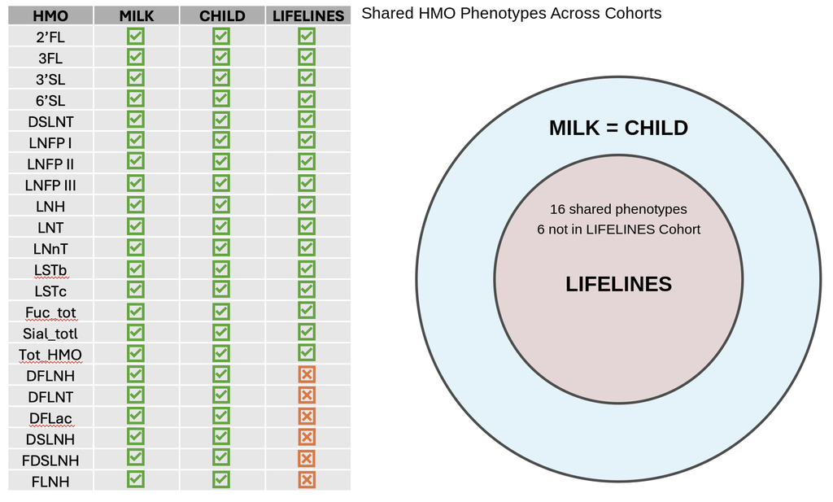

Figure 1: Shared HMO Phenotypes across MILK, CHILD, and LIFELINES cohorts. The HMO phenotypes shared across all three cohorts include: 2’FL, 3FL, 3’SL, 6’SL, DSLNT, LNFP I, LNFP II, LNFP III, LNH, LNT, LNnT, LSTb, LSTc, Fucosylated total, Sialylated total, and Total HMOs. The HMO phenotypes shared only by the MILK and CHILD cohorts include: DFLNH, DFLNT, DFLac, DSLNH, FDSLNH, and FLNH.

*Meta-analysis of all three cohorts:*

| Phenotype | CHR | BP | SNP | Effect_Allele | Other_Allele | FreqAvg | FreqSE | Beta | SE | P | Direction | HetI2 | HetPVal |
| --- | --- | --- | --- | --- | --- | --- | --- | --- | --- | --- | --- | --- | --- |
| 2FL | 19 | 5832198 | 19_5832198_G_A | a | g | 0.3704 | 0.0267 | 0.3044 | 0.0385 | 2.76e-15 | +++ | 0.0 | 8.590e-01 |
| 2FL | 19 | 48703417 | 19_48703417_G_A | a | g | 0.4323 | 0.0393 | -0.9576 | 0.0291 | 2.85e-237 | --- | 0.0 | 4.208e-01 |
| 3FL | 19 | 5820188 | 19_5820188_C_A | a | c | 0.1919 | 0.0195 | -0.3688 | 0.0469 | 3.87e-15 | --- | 91.0 | 1.492e-05 |
| 3FL | 19 | 48703346 | 19_48703346_C_T | t | c | 0.4262 | 0.0071 | -0.7560 | 0.0584 | 2.42e-38 | -?- | 0.0 | 8.393e-01 |
| 3SL | 19 | 5847989 | 19_5847989_C_T | t | c | 0.2474 | 0.0000 | -0.4431 | 0.0482 | 3.60e-20 | ?-- | 83.2 | 1.463e-02 |
| 3SL | 19 | 48700572 | 19_48700572_C_T | t | c | 0.3927 | 0.0401 | -0.3345 | 0.0386 | 4.41e-18 | --- | 89.3 | 8.451e-05 |
| 6SL | 3 | 187041559 | 3_187041559_A_G | a | g | 0.8387 | 0.0044 | -0.3005 | 0.0435 | 5.06e-12 | --- | 0.0 | 3.799e-01 |
| DSLNT | 17 | 7385193 | 17_7385193_C_A | a | c | 0.1330 | 0.0120 | -0.2993 | 0.0541 | 3.11e-08 | --+ | 78.1 | 1.031e-02 |
| DSLNT | 6 | 113224735 | 6_113224735_A_T | a | t | 0.8797 | 0.0059 | -0.3534 | 0.0633 | 2.40e-08 | ?-- | 0.0 | 9.302e-01 |
| Fuc_tot | 19 | 48703205 | 19_48703205_C_T | t | c | 0.4280 | 0.0396 | -0.8126 | 0.0308 | 1.27e-153 | --- | 95.7 | 6.674e-11 |
| LNFP_I | 19 | 5840608 | 19_5840608_C_T | t | c | 0.3240 | 0.0213 | 0.4410 | 0.0396 | 9.20e-29 | ?++ | 85.3 | 9.113e-03 |
| LNFP_I | 19 | 48703417 | 19_48703417_G_A | a | g | 0.4364 | 0.0396 | -0.8639 | 0.0268 | 3.23e-228 | --- | 90.2 | 3.816e-05 |
| LNFP_II | 19 | 5840608 | 19_5840608_C_T | t | c | 0.3276 | 0.0188 | -0.6085 | 0.0414 | 8.00e-49 | ?-- | 0.0 | 9.076e-01 |
| LNFP_II | 19 | 48703417 | 19_48703417_G_A | a | g | 0.4284 | 0.0391 | 0.8696 | 0.0316 | 5.05e-167 | +++ | 69.1 | 3.929e-02 |
| LNFP_III | 19 | 48703949 | 19_48703949_A_G | a | g | 0.5585 | 0.0426 | -0.4634 | 0.0371 | 9.31e-36 | --? | 96.4 | 1.147e-07 |
| LNH | 19 | 5819816 | 19_5819816_C_T | t | c | 0.1906 | 0.0196 | -0.3786 | 0.0456 | 1.04e-16 | --- | 72.6 | 2.602e-02 |
| LNH | 19 | 48708712 | 19_48708712_T_C | t | c | 0.5536 | 0.0489 | 0.2558 | 0.0404 | 2.39e-10 | ++? | 86.2 | 7.078e-03 |
| LNnT | 19 | 5846266 | 19_5846266_T_C | t | c | 0.9208 | 0.0137 | -0.4069 | 0.0702 | 6.79e-09 | --- | 0.0 | 6.660e-01 |
| LNnT | 19 | 48703346 | 19_48703346_C_T | t | c | 0.4261 | 0.0071 | 0.6247 | 0.0616 | 3.48e-24 | +?+ | 48.2 | 1.648e-01 |
| LNnT | 4 | 41326544 | 4_41326544_G_A | a | g | 0.1403 | 0.0122 | 0.2936 | 0.0525 | 2.30e-08 | +++ | 29.9 | 2.402e-01 |
| LNnT | 7 | 121541964 | 7_121541964_T_C | t | c | 0.6317 | 0.0174 | -0.2310 | 0.0375 | 7.13e-10 | --- | 0.0 | 6.005e-01 |
| LNT | 19 | 5840608 | 19_5840608_C_T | t | c | 0.3287 | 0.0179 | 0.2651 | 0.0445 | 2.62e-09 | ?++ | 22.5 | 2.560e-01 |
| LNT | 19 | 48705721 | 19_48705721_A_G | a | g | 0.5508 | 0.0496 | -0.4349 | 0.0356 | 2.75e-34 | --- | 0.0 | 5.261e-01 |
| LNT | 7 | 121520210 | 7_121520210_T_C | t | c | 0.6630 | 0.0242 | -0.2245 | 0.0381 | 3.84e-09 | --- | 15.1 | 3.081e-01 |
| LSTb | 19 | 48705969 | 19_48705969_G_A | a | g | 0.4485 | 0.0485 | 0.4590 | 0.0352 | 7.33e-39 | +++ | 75.3 | 1.745e-02 |
| LSTc | 19 | 48703949 | 19_48703949_A_G | a | g | 0.5563 | 0.0437 | 0.4147 | 0.0392 | 3.57e-26 | ++? | 72.5 | 5.660e-02 |
| LSTc | 3 | 187040795 | 3_187040795_C_A | a | c | 0.1612 | 0.0041 | 0.2965 | 0.0456 | 7.54e-11 | +++ | 0.0 | 5.993e-01 |
| Sial_tot | 19 | 5847989 | 19_5847989_C_T | t | c | 0.2474 | 0.0001 | -0.3562 | 0.0449 | 2.14e-15 | ?-- | 91.1 | 8.073e-04 |
| Sial_tot | 19 | 48705608 | 19_48705608_G_A | a | g | 0.4418 | 0.0468 | 0.4265 | 0.0387 | 3.14e-28 | ++? | 0.0 | 8.388e-01 |
| Tot_HMO | 19 | 48703205 | 19_48703205_C_T | t | c | 0.4282 | 0.0397 | -0.7365 | 0.0315 | 3.12e-121 | --- | 97.1 | 6.903e-16 |

Table 1: Lead SNPs identified from meta-analysis of MILK, CHILD, and LIFELINEs cohorts for 16 shared HMO phenotypes. Chromosomal positions are mapped to the GRCh38 genome.

[figure not shown]

Figure 2: Overlayed Manhattan plots from meta-analysis of MILK, CHILD, and LIFELINEs cohorts for 16 shared HMO phenotypes. Chromosomal positions are mapped to the GRCh38 genome. Genome-wide significance (gray line) is shown at P-value < 5e-8, and study-wide significance (blue line) is shown at P-value < 8.3e-9.

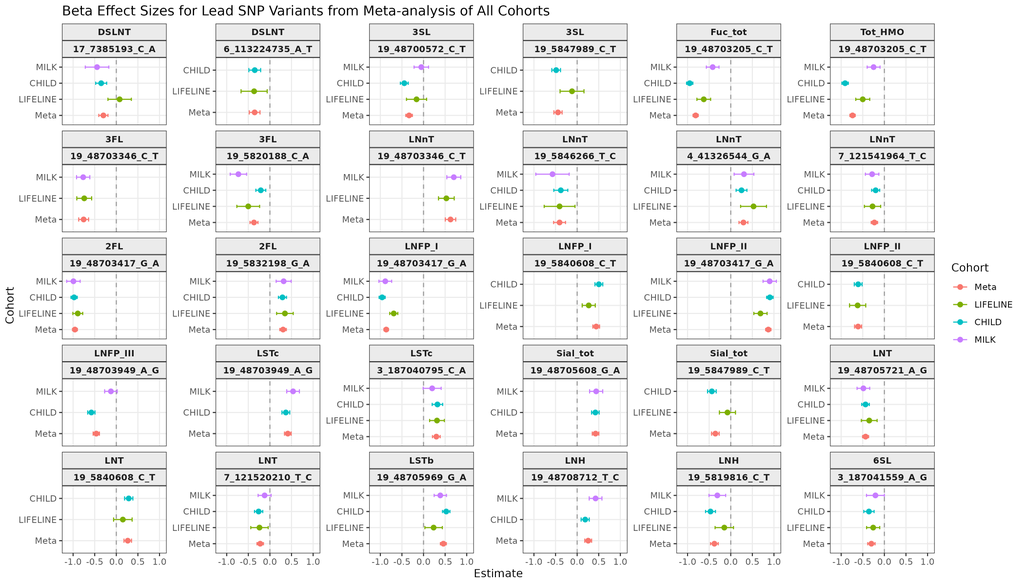

Figure 3: Forest plots displaying beta effect sizes for lead SNP variants from meta-analysis of MILK, CHILD, and LIFELINEs cohorts for 16 shared HMO phenotypes.

Among the top hits, seven different genetic loci were identified. Four of these loci (*FUT2* at Chr19:48703417, *FUT3*/*FUT6* at Chr19:5832198, *ST6GAL1* at Chr3:187041559, and *FAM3C* at Chr7: 121541964) have been previously identified in individual-level GWAS analyses to be associated with HMO concentrations (2-4).

Three additional loci were found from the meta-analysis. The SNP variant at Chr4:41326544 was found to be associated with LNnT concentration. The *LIMCH1* gene is nearest to this region, encoding a myosin II binding protein, which has been found to be involved in breast cancer biology and mammary cell epithelium (7).

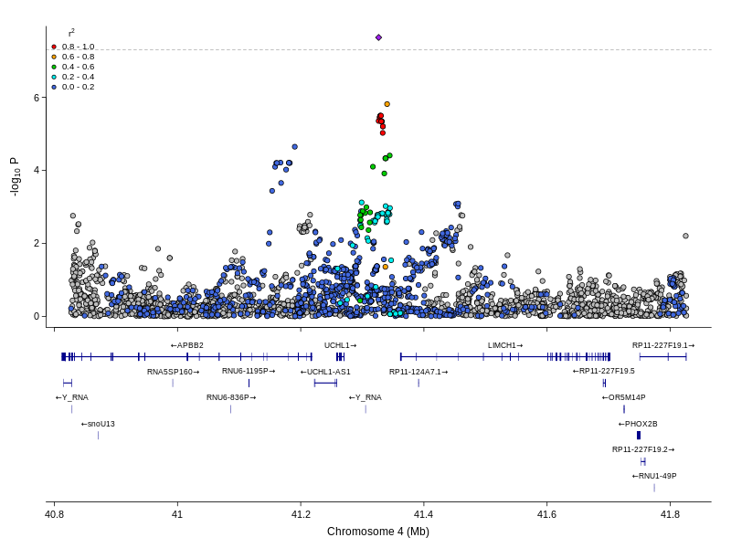

Figure 4: Locus Zoom plot of the LIMCH1 locus on chromosome 4. The lead SNP 4_41326544_G_A, highlighted by the purple diamond, was most strongly associated with LNnT concentration. The gray line represents the genome-wide significance threshold at P-value < 5e-8.

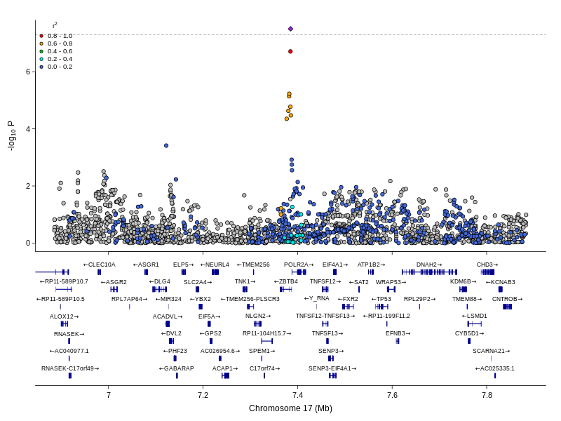

Figure 5: Locus Zoom plot of the TNK1 locus on chromosome 17. The lead SNP 17_7385193_C_A, highlighted by the purple diamond, was most strongly associated with DSLNT concentration. The gray line represents the genome-wide significance threshold at P-value < 5e-8.

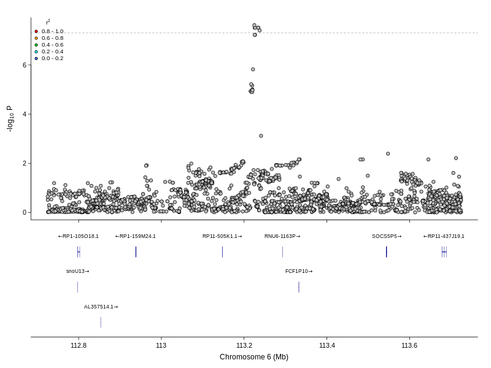

*Meta-analysis of MILK & CHILD cohorts:*

In the meta-analysis of the MILK and CHILD cohorts only, METAL processed 6,320,655 variants from the MILK cohort and 5,470,256 variants from the CHILD cohort; from these, a total of 6,320,655 variants were finally meta-analyzed.

| Phenotype | CHR | BP | SNP | Effect_Allele | Other_Allele | FreqAvg | FreqSE | Beta | SE | P | Direction | HetI2 | HetPVal |
| --- | --- | --- | --- | --- | --- | --- | --- | --- | --- | --- | --- | --- | --- |
| DFLac | 19 | 48703417 | 19_48703417_G_A | a | g | 0.4207 | 0.0373 | -0.7614 | 0.0363 | 6.72e-98 | -- | 0.0 | 6.980e-01 |
| DFLNH | 19 | 48704461 | 19_48704461_T_C | t | c | 0.5550 | 0.0445 | 0.3613 | 0.0364 | 3.60e-23 | -+ | 99.2 | 6.861e-30 |
| DFLNT | 19 | 5833268 | 19_5833268_G_A | a | g | 0.3810 | 0.0088 | -0.5828 | 0.0389 | 1.15e-50 | -- | 0.0 | 6.053e-01 |
| DFLNT | 19 | 48703205 | 19_48703205_C_T | t | c | 0.4256 | 0.0409 | -0.5069 | 0.0383 | 5.18e-40 | -- | 72.2 | 5.767e-02 |
| DSLNH | 19 | 5827754 | 19_5827754_G_A | a | g | 0.0620 | 0.0100 | -0.4725 | 0.0823 | 9.35e-09 | -- | 0.0 | 9.598e-01 |
| DSLNH | 3 | 187041559 | 3_187041559_A_G | a | g | 0.8380 | 0.0050 | -0.3105 | 0.0523 | 2.90e-09 | -- | 0.0 | 6.412e-01 |
| FDSLNH | 19 | 5844781 | 19_5844781_A_C | a | c | 0.8699 | 0.0220 | 0.5969 | 0.0589 | 3.84e-24 | ++ | 66.2 | 8.558e-02 |
| FDSLNH | 19 | 48703417 | 19_48703417_G_A | a | g | 0.4206 | 0.0373 | 0.7879 | 0.0358 | 1.29e-107 | ++ | 0.0 | 4.291e-01 |
| FLNH | 15 | 59544557 | 15_59544557_C_T | t | c | 0.4660 | 0.0065 | -0.2195 | 0.0385 | 1.17e-08 | -- | 77.7 | 3.407e-02 |

Table 2: Lead SNPs identified from meta-analysis of MILK and CHILD cohorts for 6 shared HMO phenotypes. Chromosomal positions are mapped to the GRCh38 genome.

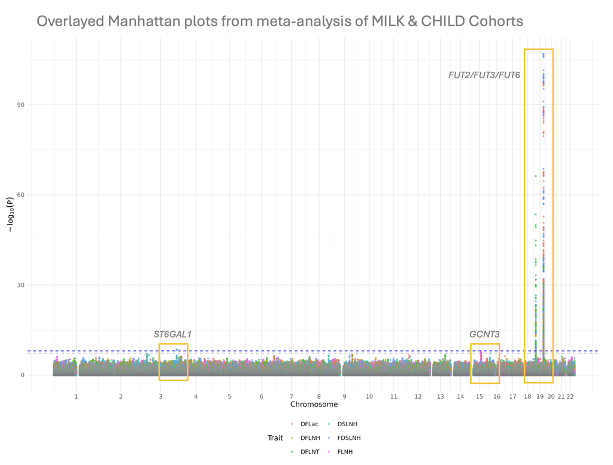

Figure 7: Overlayed Manhattan plots from meta-analysis of MILK and CHILD cohorts for 6 shared HMO phenotypes. Chromosomal positions are mapped to the GRCh38 genome. Genome-wide significance (gray line) is shown at P-value < 5.0e-8, and study-wide significance (blue line) is shown at P-value < 8.3e-9.

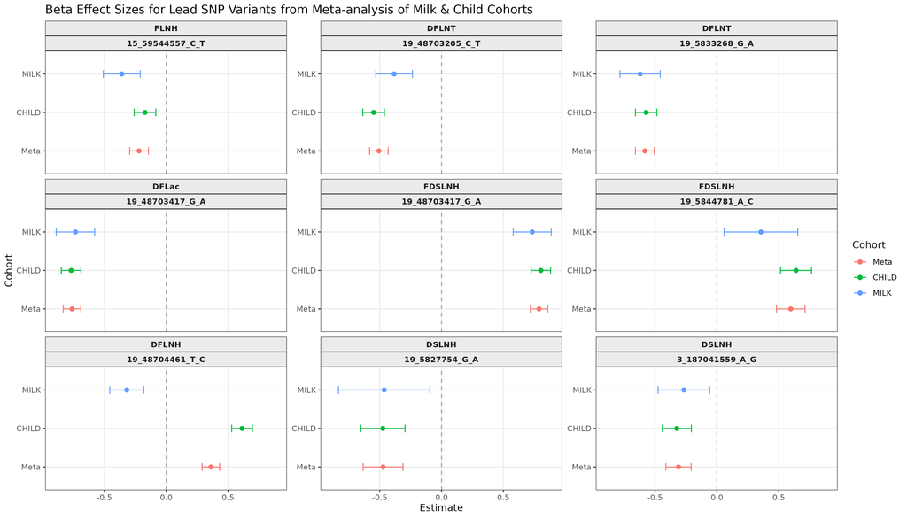

Figure 8: Forest plots displaying beta effect sizes for lead SNP variants from meta-analysis of MILK and CHILD cohorts for 6 shared phenotypes.

From this secondary meta-analysis, one additional genetic locus was identified: the SNP variant at Chr15:59544557 was found to be associated with FLNH concentration. In this region, the nearby *GCNT3* gene, which encodes a N-acetylglucosaminyltransferase enzyme, can be found. This enzyme has been previously associated with milk production in humans (3).

## **Discussion & Limitations:**

In this project, meta-analysis pipelines were utilized to improve statistical power and reveal novel genetic associations with HMO composition in human milk. Meta-analysis of GWAS summary statistics from three independent cohorts initially identified seven genetic loci with associations to HMO composition, and a subsequent MILK+CHILD meta-analysis identified one additional locus, for eight loci total. Of these loci, three loci (*TNK1*, *LIMCH1*, and *SOCS5P5*) were not previously reported to be associated with HMO composition and therefore represent potentially novel associations.

Although meta-analysis substantially increased statistical power and enabled the identification of eight genetic loci associated with HMO composition, including three novel loci, several limitations should be considered. First, the identified associations are statistical and do not establish causal relationships or identify the underlying causal variants or genes. At the time of this study, downstream functional analyses, such as fine-mapping, colocalization, expression quantitative trait locus (eQTL) analyses, transcriptome-wide association studies (TWAS), or experimental validation, have not yet been performed. As a result, the biological mechanisms linking these loci to HMO biosynthesis remain unresolved, and these loci are candidate regions for future investigation.

Additionally, differences in cohort characteristics, sample sizes, and phenotype measurement protocols may have introduced residual heterogeneity despite the use of meta-analysis methods. Finally, because the study population was limited to the available cohorts, of which were predominantly European ancestry, the generalizability of these findings to other ancestral populations remains to be determined. Future work incorporating functional genomics, experimental validation, and more diverse populations will be essential for confirming the causal genes and elucidating the biological pathways underlying these associations. Therefore, the novel loci reported here should be considered candidate regions for future investigation rather than definitive evidence of the genes or molecular pathways regulating HMO composition.

## References:

1. Kellman, Benjamin P et al. “Elucidating Human Milk Oligosaccharide biosynthetic genes through network-based multi-omics integration.” Nature communications vol. 13,1 2455. 4 May. 2022, doi:10.1038/s41467-022-29867-4

2. Johnson, Kelsey E et al. “Human milk variation is shaped by maternal genetics and impacts the infant gut microbiome.” *Cell genomics* vol. 4,10 (2024): 100638. doi:10.1016/j.xgen.2024.100638

3. Ambalavanan, A., Chang, L., Choi, J. *et al.* “Human milk oligosaccharides are associated with maternal genetics and respiratory health of human milk-fed children.” *Nat Commun* **15**, 7735 (2024). https://doi.org/10.1038/s41467-024-51743-6

4. Spreckels J, Kurilshikov A, Fernández-Pato A et al. “Host and environmental determinants of human milk oligosaccharides and microbiota in the Lifelines NEXT cohort” *Cell Reports*, 2025; 44

5. Hinrichs AS, Karolchik D, Baertsch R, Barber GP, Bejerano G, Clawson H, Diekhans M, Furey TS, Harte RA, Hsu F *et al*. [**The UCSC Genome Browser Database: update 2006**](https://academic.oup.com/nar/article-lookup/doi/10.1093/nar/gkj144). *Nucleic Acids Res*. 2006 Jan 1;34(Database issue):D590-8.

6. Willer, Cristen J et al. “METAL: fast and efficient meta-analysis of genomewide association scans.” *Bioinformatics (Oxford, England)* vol. 26,17 (2010): 2190-1. doi:10.1093/bioinformatics/btq340

7. Qiu, M., Gao, Z., Tian, M. *et al.* LIMCH1 inhibits antitumor immunity by upregulating PDL1 in triple-negative breast cancer. *Cell Commun Signal* **23**, 419 (2025). https://doi.org/10.1186/s12964-025-02387-6

8. Fang, Chao et al. “Unveiling Genetic Markers for Milk Yield in Xinjiang Donkeys: A Genome-Wide Association Study and Kompetitive Allele-Specific PCR-Based Approach.” *International journal of molecular sciences* vol. 26,7 2961. 25 Mar. 2025, doi:10.3390/ijms26072961

9. Arun, Sondur J et al. “Targeted Analysis Reveals an Important Role of JAK-STAT-SOCS Genes for Milk Production Traits in Australian Dairy Cattle.” *Frontiers in genetics* vol. 6 342. 15 Dec. 2015, doi:10.3389/fgene.2015.00342